# Bioreactor_Stats_Report

# Data Input and Cleanup

Read in PFAS and methane production data from database file. Also stored analytical LOQs and reactor coding by experimental factor.

```r
raw.inputs <- read_excel('Reactor Raws/Johnsie Clean Data 2.xlsx', sheet = 2)

CH4.inputs <- read_excel('Reactor Raws/Johnsie Clean Data 2.xlsx', sheet = 1)

LoQs <- read_excel('Reactor Raws/Johnsie Clean Data 2.xlsx', sheet = 3)
LOQs <- structure(as.numeric(LoQs), names=colnames(LoQs))

codings <- read_excel('Reactor Raws/Johnsie Clean Data 2.xlsx', sheet = 5) %>%
  mutate(crossed_factors = paste0(Season,"_",biotype)) %>%
  group_by(crossed_factors)%>%
  mutate(dummy_rep = seq_along(crossed_factors))

codings
```

```
## # A tibble: 16 x 5
## # Groups:   crossed_factors [8]
##    Reactor Season biotype crossed_factors dummy_rep
##    <chr>   <chr>  <chr>   <chr>               <int>
##  1 P2      Fall   live    Fall_live               1
##  2 P3      Fall   live    Fall_live               2
##  3 P4      Fall   abio    Fall_abio               1
##  4 P5      Fall   abio    Fall_abio               2
##  5 P6      Winter live    Winter_live             1
##  6 P8      Winter abio    Winter_abio             1
##  7 P9      Winter abio    Winter_abio             2
##  8 P20     Spring live    Spring_live             1
##  9 P21     Spring live    Spring_live             2
## 10 P22     Spring abio    Spring_abio             1
## 11 P23     Spring abio    Spring_abio             2
## 12 P24     Summer live    Summer_live             1
## 13 P25     Summer live    Summer_live             2
## 14 P26     Summer abio    Summer_abio             1
## 15 P27     Summer abio    Summer_abio             2
## 16 P7      Winter live    Winter_live             2
```

```r
as.tibble(LOQs)
```

```
## # A tibble: 70 x 1
##    value
##  * <dbl>
##  1 59.1
##  2 26.4
##  3  6.84
##  4  4.17
##  5  2.99
##  6  2
##  7  2
##  8  2
##  9  2
## 10  2
## # ... with 60 more rows
```

Single point imputation of missing data. Non-measurements days were dropped from the dataframe, values reported below LOQ were inputted at LoQ/sqrt(2), values as zero or ND were set at LOQ/10. These values will be replaced by later multipoint inputation on a per-compound basis if/when necessary.

```r
clean_data <- raw.inputs %>%
  dplyr::filter(!is.na(PFBA)) %>%
  dplyr::select(-`Sample Date`, -`Date Analyzed`)

for (i in 1:length(LOQs)) {
  n = i+2
  clean_data[which(clean_data[,(n)] == "<LOQ"),(n)] <- LOQs[i]/sqrt(2)
  clean_data[which(clean_data[,(n)] == "LOQ"),(n)] <- LOQs[i]/sqrt(2)
  clean_data[which(clean_data[,(n)] == "ND"),(n)] <- LOQs[i]/10
  clean_data[which(clean_data[,(n)] == "0"),(n)] <- LOQs[i]/10
}

clean_data2 <- clean_data %>%
  mutate_at(colnames(clean_data[2:72]), as.numeric)
```

Methane production levels used to define reactor “phases”.“Lag” phase is the initial phase with production < 0.2, “decline” phase is the final phase with production < 0.2. “Peak” phase is the period of microbe activity. Phases will be used if strict Days.Elapsed models fail.

```r
CH4.phase <- CH4.inputs %>%
  group_by(Reactor) %>%
  summarize(max.CH4 = max(CH4)) %>%
  left_join(CH4.inputs) %>%
  mutate(peak.day = ifelse((CH4 == max.CH4), Days.Elapsed,NA)) %>%
  dplyr::filter(!is.na(peak.day)) %>%
  dplyr::select(peak.day,Reactor)%>%
  full_join(CH4.inputs) %>%
  mutate(phase = ifelse(CH4 < 0.2 & Days.Elapsed < peak.day, "lag", "peak"),
         phase = ifelse(CH4 < 0.2 & Days.Elapsed > peak.day, "decline", phase)) %>%
  dplyr::select(Days.Elapsed,Reactor,phase) %>%
  dplyr::filter(!is.na(phase))
CH4.phase
```

```
## # A tibble: 258 x 3
##    Days.Elapsed Reactor phase
##           <dbl> <chr>   <chr>
##  1         0    P2      lag
##  2         2.84 P2      lag
##  3         4.94 P2      lag
##  4        11.0  P2      lag
##  5        25.9  P2      lag
##  6        32.8  P2      lag
##  7        45.0  P2      lag
##  8        66.8  P2      lag
##  9        73.9  P2      lag
## 10        78.8  P2      peak
## # ... with 248 more rows
```

```r
phase_factoring <- function(df,reactor.list,lag.knot,decline.knot) {
  df %>% mutate(phase = case_when(Reactor %in% reactor.list & Days.Elapsed <= lag.knot ~ "lag",
                                  Reactor %in% reactor.list & Days.Elapsed > lag.knot & Days.Elapsed < decline.knot ~ "peak",
                                  Reactor %in% reactor.list & Days.Elapsed >= decline.knot ~ "decline",
                                  TRUE ~ as.character(phase)))

}

## assigned manually because I am too tired to write a general function
final_raw <- clean_data2 %>% full_join(codings, by = "Reactor") %>%
  mutate(phase = "waiting") %>%
  phase_factoring(c("P2"), 74, 220)%>%
  phase_factoring(c("P3"), 311, 458)%>%
  phase_factoring(c("P20"), 75, 335)%>%
  phase_factoring(c("P21"), 67, 257)%>%
  phase_factoring(c("P24"), 20, 140)%>%
  phase_factoring(c("P25"), 33, 208)%>%
  phase_factoring(c("P25"), 33, 208)%>%
  phase_factoring(c("P7"), 20, 132)%>%
  phase_factoring(c("P6"), 54, 193)%>%
  phase_factoring(c("P4","P5"), 74, 220) %>%
  phase_factoring(c("P22","P23"), 109, 296)%>%
  phase_factoring(c("P26","P27"),26, 174) %>%
  phase_factoring(c("P8","P9"), 37, 163) %>%
  mutate_at(c("Reactor", "Season", "biotype","phase"), as.factor)

final_raw
```

```
## # A tibble: 211 x 78
##    Days.Elapsed   dil  PFBA PFPeA PFHxA PFHpA  PFOA  PFNA  PFDA PFUnDA
##           <dbl> <dbl> <dbl> <dbl> <dbl> <dbl> <dbl> <dbl> <dbl>  <dbl>
##  1            0  1     59.8  36.5  52.4  49.1  72.9  7.70  4.66   3.49
##  2            5  1.02  41.8  45.5  63.3  52.3  71.9  5.00  3.32   4.73
##  3           12  1.04  41.8  42.6  58.4  56.0  97.5  5.85  1.41   1.41
##  4           17  1.05  41.8  62.2  71.6  59.7  98.3  5.92  4.75   2.82
##  5           26  1.05  41.8  46.7  61.4  54.3  85.2  6.12  4.24   3.68
##  6           33  1.07  65.9  53.9  71.3  52.2 101.  10.8   0.2    6.82
##  7           47  1.10  83.4  43.1  76.4  52.3  97.2  4.75  2.39   4.57
##  8           60  1.10  41.8  52.8  76.8  60.8 116.   9.58  0.2    0.2
##  9           74  1.46  73.6  29.3  48.5  31.0  77.7  8.42  3.53   2.83
## 10           88  1.46  58.2  26.3  46.1  36.6  82.7  6.91  2.44   2.04
## # ... with 201 more rows, and 68 more variables: PFDoDA <dbl>,
## #   PFTriDA <dbl>, PFTeDA <dbl>, PFPeDA <dbl>, PFHxDA <dbl>, PFHpDA <dbl>,
## #   PFOcDA <dbl>, FBEA <dbl>, FHEA <dbl>, FOEA <dbl>, FDEA <dbl>,
## #   FBUEA <dbl>, FHUEA <dbl>, FOUEA <dbl>, FDUEA <dbl>, FPrPA <dbl>,
## #   FPePA <dbl>, FHpPA <dbl>, FNPA <dbl>, PFBS <dbl>, PFPS <dbl>,
## #   PFHxS <dbl>, PFHpS <dbl>, PFOS <dbl>, PFNS <dbl>, PFDS <dbl>,
## #   FTS.4.2 <dbl>, FTS.6.2 <dbl>, FTS.8.2 <dbl>, FBSAA <dbl>,
## #   FPeSAA <dbl>, FHxSAA <dbl>, FHpSAA <dbl>, FOSAA <dbl>, MeFBSAA <dbl>,
## #   MeFPeSAA <dbl>, MeFHxSAA <dbl>, MeFHpSAA <dbl>, MeFOSAA <dbl>,
## #   EtFBSAA <dbl>, EtFPeSAA <dbl>, EtFHxSAA <dbl>, EtFHpSAA <dbl>,
## #   EtFOSAA <dbl>, PFPi.4.4 <dbl>, PFPi.4.6 <dbl>, PFPi.6.6 <dbl>,
## #   PFPi.8.6 <dbl>, PFPi.8.8 <dbl>, diPAP.4.2 <dbl>, diPAP.4.2.6.2 <dbl>,
## #   diPAP.6.2 <dbl>, diPAP.6.2.8.2 <dbl>, diPAP.8.2 <dbl>,
## #   diPAP.8.2.10.2 <dbl>, diPAP.10.2 <dbl>, FTMAP.6.2 <dbl>,
## #   FTMAP.6.2.8.2 <dbl>, FTMAP.8.2 <dbl>, FTMAP.8.2.10.2 <dbl>,
## #   FTMAP.10.2 <dbl>, SAmPAP <dbl>, Reactor <fct>, Season <fct>,
## #   biotype <fct>, crossed_factors <chr>, dummy_rep <int>, phase <fct>
```

# Exploratory Data Analysis

## Overall Summaries

Calculate some summary stats for each PFAS measurement across all reactors to see what we are working with.

```r
PFASs <- colnames(final_raw)[3:72]

means <- final_raw[PFASs] %>%
  summarize_all(.funs = funs(mean))
median <- final_raw[PFASs] %>%
  summarize_all(.funs = funs(median))
sd <- final_raw[PFASs] %>%
  summarize_all(.funs = funs(sd))
min <- final_raw[PFASs] %>%
  summarize_all(.funs = funs(min))
max <- final_raw[PFASs] %>%
  summarize_all(.funs = funs(max))

summaries <- bind_rows(means,median,sd,min,max) %>% as.data.frame()
rownames(summaries) <- c("mean","median","sd","min","max")

round(as.tibble(summaries), 2)
```

```
## # A tibble: 5 x 70
##     PFBA PFPeA  PFHxA  PFHpA   PFOA  PFNA  PFDA PFUnDA PFDoDA PFTriDA
## *  <dbl> <dbl>  <dbl>  <dbl>  <dbl> <dbl> <dbl>  <dbl>  <dbl>   <dbl>
## 1  48.5  30.3   75.0   45.7   55.4   7.12  3.05   2.15   2.3     1.86
## 2  41.8  26.2   67.7   43.2   47.9   6.14  1.41   1.41   1.41    1.41
## 3  27.7  15.9   38.9   22.0   33.1   4.92  3.37   2.72   3.26    2.94
## 4   5.91  2.64   6.93   5.29   8.07  1.41  0.2    0.2    0.2     0.2
## 5 151.   76.7  240.   132.   149.   24.8  17.6   15.2   16.6    18.7
## # ... with 60 more variables: PFTeDA <dbl>, PFPeDA <dbl>, PFHxDA <dbl>,
## #   PFHpDA <dbl>, PFOcDA <dbl>, FBEA <dbl>, FHEA <dbl>, FOEA <dbl>,
## #   FDEA <dbl>, FBUEA <dbl>, FHUEA <dbl>, FOUEA <dbl>, FDUEA <dbl>,
## #   FPrPA <dbl>, FPePA <dbl>, FHpPA <dbl>, FNPA <dbl>, PFBS <dbl>,
## #   PFPS <dbl>, PFHxS <dbl>, PFHpS <dbl>, PFOS <dbl>, PFNS <dbl>,
## #   PFDS <dbl>, FTS.4.2 <dbl>, FTS.6.2 <dbl>, FTS.8.2 <dbl>, FBSAA <dbl>,
## #   FPeSAA <dbl>, FHxSAA <dbl>, FHpSAA <dbl>, FOSAA <dbl>, MeFBSAA <dbl>,
## #   MeFPeSAA <dbl>, MeFHxSAA <dbl>, MeFHpSAA <dbl>, MeFOSAA <dbl>,
## #   EtFBSAA <dbl>, EtFPeSAA <dbl>, EtFHxSAA <dbl>, EtFHpSAA <dbl>,
## #   EtFOSAA <dbl>, PFPi.4.4 <dbl>, PFPi.4.6 <dbl>, PFPi.6.6 <dbl>,
## #   PFPi.8.6 <dbl>, PFPi.8.8 <dbl>, diPAP.4.2 <dbl>, diPAP.4.2.6.2 <dbl>,
## #   diPAP.6.2 <dbl>, diPAP.6.2.8.2 <dbl>, diPAP.8.2 <dbl>,
## #   diPAP.8.2.10.2 <dbl>, diPAP.10.2 <dbl>, FTMAP.6.2 <dbl>,
## #   FTMAP.6.2.8.2 <dbl>, FTMAP.8.2 <dbl>, FTMAP.8.2.10.2 <dbl>,
## #   FTMAP.10.2 <dbl>, SAmPAP <dbl>
```

Some compounds show basically zero variation, others aren’t detected hardly at all. Analysis will proceed on the “interesting” subset of compounds selected by Lang (DOI: 10.1021/acs.est.6b05005) with an additional filter to require a max detected concentration of 10. Other samples have too little variation to model.

```r
PFASs_subset <- c("PFBA","PFPeA","PFHxA","PFHpA","PFOA","PFNA","PFDA",
  "FHEA","FHUEA","FPePA","FOEA","FHpPA",
  "PFBS","PFHxS","PFOS",
  "MeFBSAA","FTS.6.2","diPAP.6.2","diPAP.6.2.8.2","diPAP.8.2")

subset2 <- PFASs_subset[which(summaries["max",PFASs_subset] > 10)]

working_raws <- final_raw[subset2] %>%
  cbind(final_raw[c("Days.Elapsed","dil","Reactor","Season","biotype","phase")])

summary_plot <- working_raws %>%
  gather(one_of(subset2), key = "PFAS", value = "raw_measure") %>%
  mutate(conc = raw_measure * dil)

as.tibble(summary_plot)
```

```
## # A tibble: 3,376 x 9
##    Days.Elapsed   dil Reactor Season biotype phase PFAS  raw_measure  conc
##           <dbl> <dbl> <fct>   <fct>  <fct>   <fct> <chr>       <dbl> <dbl>
##  1            0  1    P2      Fall   live    lag   PFBA         59.8  59.8
##  2            5  1.02 P2      Fall   live    lag   PFBA         41.8  42.6
##  3           12  1.04 P2      Fall   live    lag   PFBA         41.8  43.3
##  4           17  1.05 P2      Fall   live    lag   PFBA         41.8  43.7
##  5           26  1.05 P2      Fall   live    lag   PFBA         41.8  44.1
##  6           33  1.07 P2      Fall   live    lag   PFBA         65.9  70.6
##  7           47  1.10 P2      Fall   live    lag   PFBA         83.4  91.5
##  8           60  1.10 P2      Fall   live    lag   PFBA         41.8  45.9
##  9           74  1.46 P2      Fall   live    lag   PFBA         73.6 107.
## 10           88  1.46 P2      Fall   live    peak  PFBA         58.2  85.1
## # ... with 3,366 more rows
```

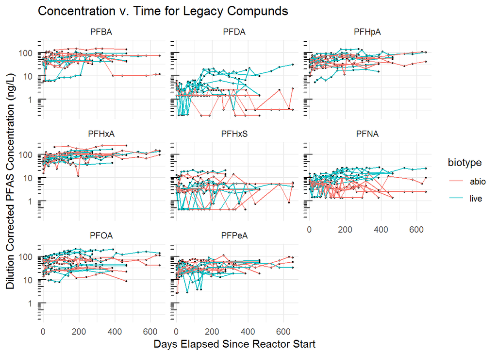

```r
##### LEGACY COMPOUNDS #####

legacy_summary <- filter(summary_plot, PFAS %in% c("PFBA","PFDA","PFOA","PFHpA","PFHxA","PFNA","PFOA","PFOS","PFPeA", "PFHxS"))

ggplot(filter(legacy_summary)) +
  theme_minimal()+
  geom_point(aes(x = Days.Elapsed, y = conc, group = Reactor), size = 0.5) +
  geom_line(aes(x = Days.Elapsed, y = conc, group = Reactor, color = biotype)) +
  scale_y_log10() +
  annotation_logticks(sides = "l")+
  facet_wrap(~PFAS) +
  labs(title ="Concentration v. Time for Legacy Compunds",
       x ="Days Elapsed Since Reactor Start",
       y ="Dilution Corrected PFAS Concentration (ng/L)")
```

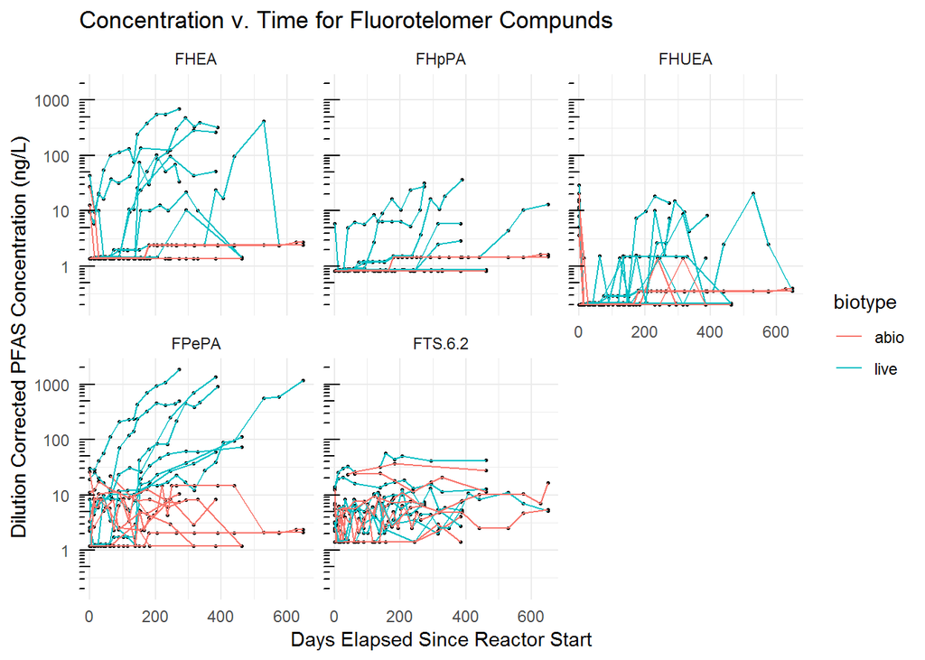

```r
##### F COMPOUNDS #####
telomer_summary <- filter(summary_plot, PFAS %in% c("FHEA","FHUEA","FPePA","FHpPA","FTS.6.2"))

ggplot(filter(telomer_summary)) +
  theme_minimal()+
  geom_point(aes(x = Days.Elapsed, y = conc, group = Reactor), size = 0.5) +
  geom_line(aes(x = Days.Elapsed, y = conc, group = Reactor, color = biotype)) +
  scale_y_log10() +
  annotation_logticks(sides = "l")+
  facet_wrap(~PFAS) +
  labs(title ="Concentration v. Time for Fluorotelomer Compunds",
       x ="Days Elapsed Since Reactor Start",
       y ="Dilution Corrected PFAS Concentration (ng/L)")
```

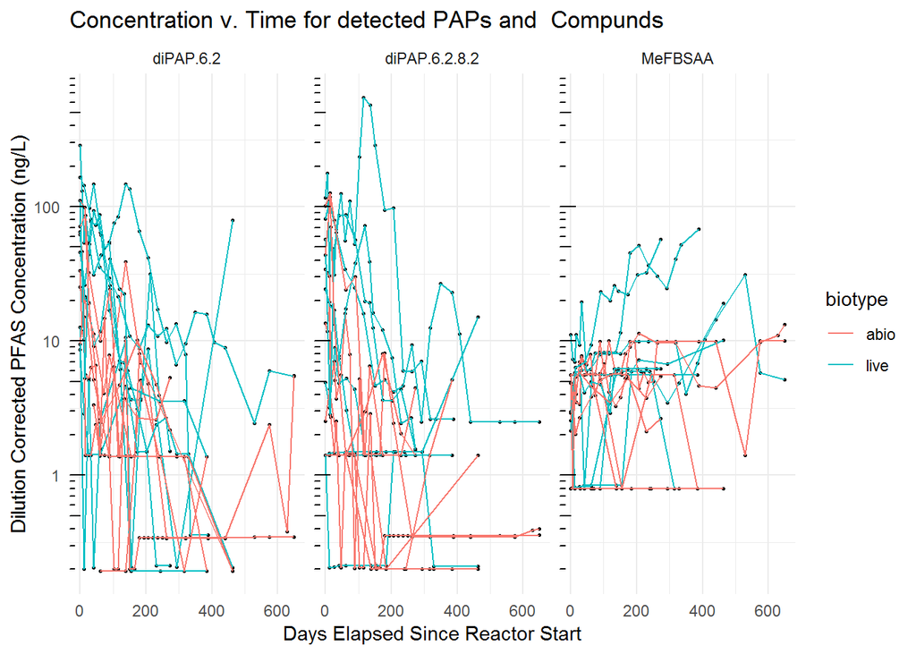

```r
###### OTHER COMPOUNDS #####

other_summary <- filter(summary_plot, ! PFAS %in% telomer_summary$PFAS & ! PFAS %in% legacy_summary$PFAS)

ggplot(filter(other_summary)) +
  theme_minimal()+
  geom_point(aes(x = Days.Elapsed, y = conc, group = Reactor), size = 0.5) +
  geom_line(aes(x = Days.Elapsed, y = conc, group = Reactor, color = biotype)) +
  scale_y_log10() +
  annotation_logticks(sides = "l")+
  facet_wrap(~PFAS)+
  labs(title ="Concentration v. Time for detected PAPs and  Compunds",
       x ="Days Elapsed Since Reactor Start",
       y ="Dilution Corrected PFAS Concentration (ng/L)")
```

## Legacy Compound Modeling

### PFBA

Select PFBA for individual compound analysis. Exploratory graphs.

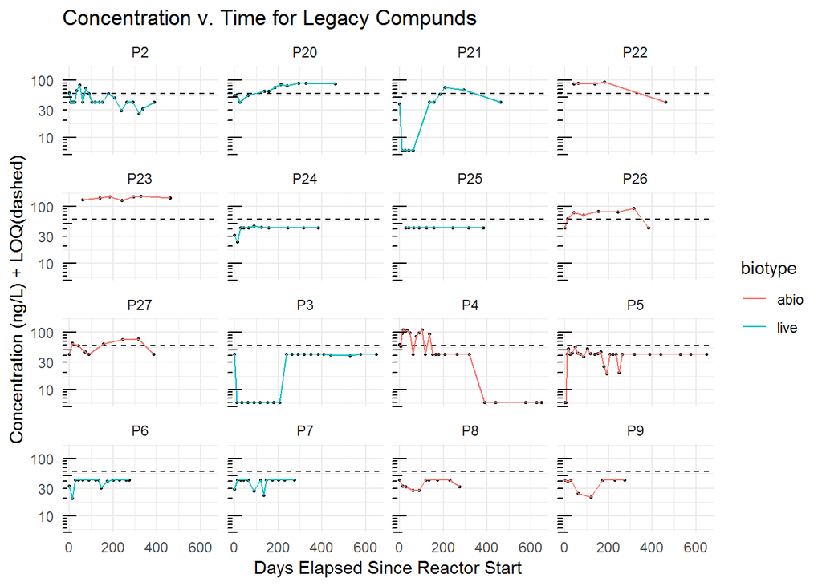

```r
chosen_PFAS <- "PFBA"

single_PFAS <- filter(summary_plot, PFAS == chosen_PFAS)

levels(single_PFAS$phase) <- c("lag", "peak","decline")

ggplot(single_PFAS) +
  geom_hline(yintercept = LOQs[chosen_PFAS], linetype = 2)+
  theme_minimal()+
  geom_point(aes(x = Days.Elapsed, y = raw_measure, group = Reactor), size = 0.5) +
  geom_line(aes(x = Days.Elapsed, y = raw_measure, group = Reactor, color = biotype)) +
  scale_y_log10() +
  annotation_logticks(sides = "l")+
  facet_wrap(~Reactor) +
  labs(title ="Concentration v. Time for Legacy Compunds",
       x ="Days Elapsed Since Reactor Start",
       y ="Concentration (ng/L) + LOQ(dashed)")
```

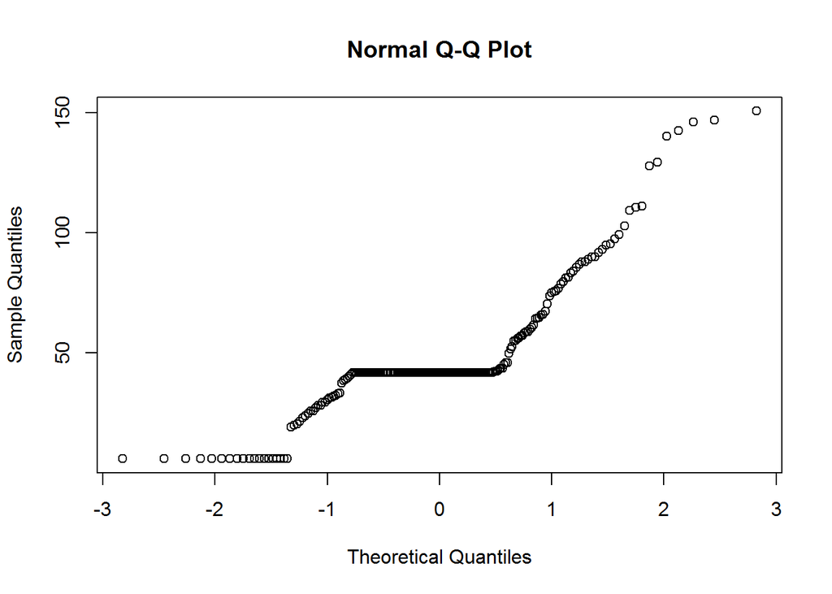

```r
qqnorm(single_PFAS$raw_measure)
```

Single value inputation is pretty clear from the QQ plot. LOQ is very high (~60ng/L) so 80% of measures should be some inputed value.

#### PFBA Multi-Value Inputation

Fit a log-normal distribution based on truncated distribution with censored data (using *fitdistrplus*)

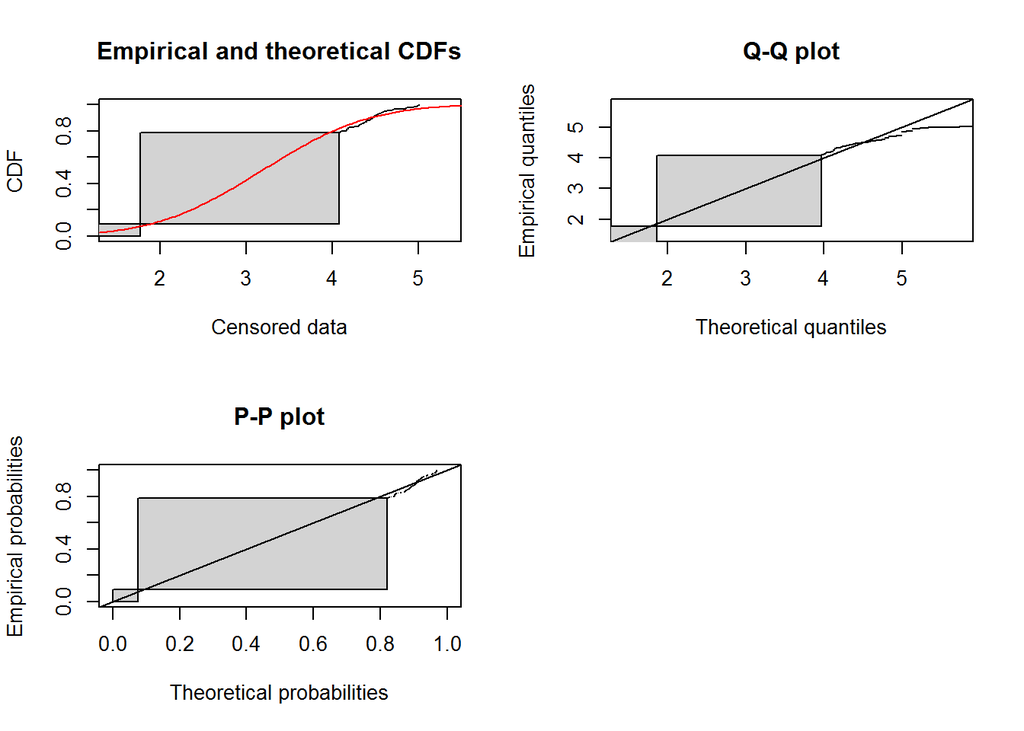

```r
fitting_values <- tibble(raw_measure = single_PFAS$raw_measure) %>%
  mutate(index1 = seq_len(nrow(.))) %>%
  sample_n(size = nrow(.)) %>%
  mutate(index2 = seq_len(nrow(.)))

lower_bound <- round(LOQs[chosen_PFAS]/10, 5)
sqrtloq <- round(LOQs[chosen_PFAS]/sqrt(2), 5)
cutoff <- round(LOQs[chosen_PFAS],5)

fitting_values <-  fitting_values %>%
  arrange(raw_measure) %>%
  mutate(raw_measure = round(raw_measure, 5)) %>%
  mutate(left = case_when(raw_measure <= lower_bound ~ as.numeric(NA),
                          raw_measure <= cutoff ~ lower_bound,
                          TRUE ~ raw_measure)) %>%
  mutate(right = case_when(raw_measure == lower_bound ~ lower_bound,
                           raw_measure <= cutoff ~ cutoff,
                           TRUE ~ raw_measure)) %>%
  arrange(raw_measure)

censdata <- fitting_values[c("left","right")] %>% as.data.frame() %>% arrange(left)

trunc_dist <- fitdistcens(log(censdata), distr = "norm")

plot(trunc_dist)
```

Reasonable fit I guess, we really are inputing 80% of the data so I am not sure it is actually meaningful.

#### PFBA Multi-Point Inputation

Going to do multi-point inputation instead of single point inputation. Assigned a random index to each censored data point, then fit with quantiles from the distribution fit above.

```r
trunc_quantiles <- unlist(quantile(trunc_dist, probs = seq(0,100,by=(100/(max(fitting_values$index1)+2)))/100)[1])[-1]

lowestcens <- sum(fitting_values$raw_measure <= lower_bound)
lowercens <- sum(fitting_values$raw_measure <= cutoff) - lowestcens

lowestcens_quatiles <- trunc_quantiles[1:lowestcens]
lowercens_quantiles <- trunc_quantiles[(lowestcens+1):(lowestcens+lowercens)]

inputions <- c(lowestcens_quatiles,lowercens_quantiles)

length(inputions) <- nrow(fitting_values)

inputed_frame <- cbind(fitting_values, inputions) %>%
  arrange(index1) %>%
  mutate(quantiles = ifelse(is.na(inputions), log(raw_measure), inputions)) %>%
  dplyr::select(quantiles) %>%
  cbind(single_PFAS) %>%
  mutate(conc = ifelse(raw_measure < LOQs[chosen_PFAS], exp(quantiles) * dil, raw_measure*dil)) %>%
  left_join(codings) %>%
  mutate(scaled_days = Days.Elapsed/100)
```

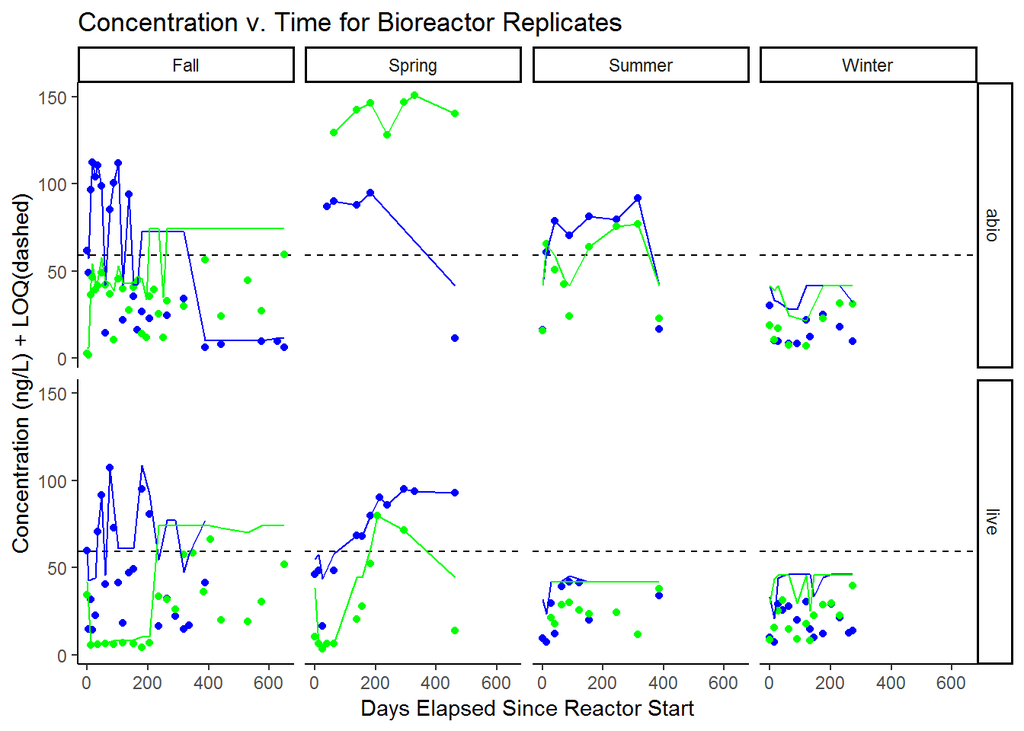

Inputed data points overlaid on line plot of original reported values

```r
graph <- ggplot(inputed_frame, aes(x = Days.Elapsed, group = Reactor)) +
  theme_classic()+
  guides(color = FALSE, fill =FALSE, linetype = FALSE)+
  geom_hline(yintercept = LOQs[chosen_PFAS], linetype = 2) +
  geom_point(aes(y = conc,
                 color = as.factor(dummy_rep))) +
  geom_line(aes(y = raw_measure*dil,
                color = as.factor(dummy_rep))) +
  scale_color_manual(values = c("blue","green"))+
  facet_grid(biotype~Season) +
  labs(title ="Concentration v. Time for Bioreactor Replicates",
       x ="Days Elapsed Since Reactor Start",
       y ="Concentration (ng/L) + LOQ(dashed)")

plot(graph)
```

Added noise should allow for modeling.

#### PFBA Modeling

Building linear mixed effect models to account for experimental factors and nesting of Reactor %in% Season. Using scaled_days (Days/100) to allow for model convergence, this effect can be reversed during model interpretation.

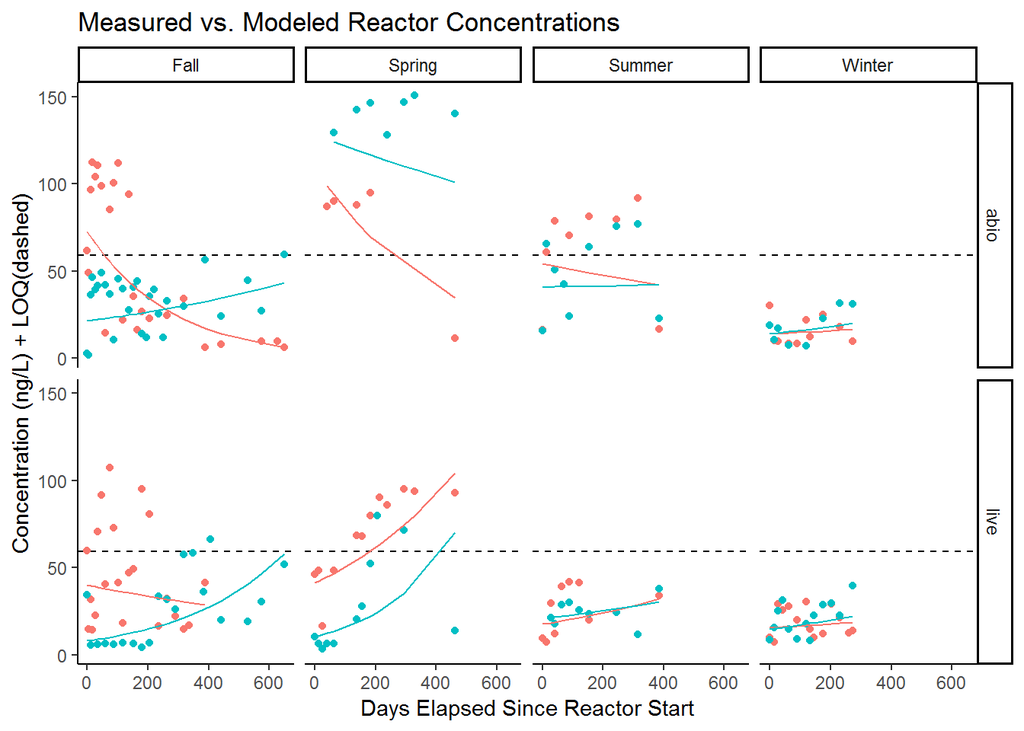

```r
model <- lmer(data = inputed_frame,
              log(conc) ~ scaled_days * biotype + Season + (scaled_days|Reactor))

ggplot(inputed_frame, aes(x = Days.Elapsed, group = Reactor)) +
  theme_classic()+
  guides(color = FALSE, fill =FALSE, linetype = FALSE)+
  geom_hline(yintercept = LOQs[chosen_PFAS], linetype = 2) +
  geom_point(aes(y = conc,
                 color = as.factor(dummy_rep))) +
  geom_line(aes(y = exp(predict(model)),
                color = as.factor(dummy_rep))) +
  facet_grid(biotype~Season) +
  labs(title ="Measured vs. Modeled Reactor Concentrations",
       x ="Days Elapsed Since Reactor Start",
       y ="Concentration (ng/L) + LOQ(dashed)")
```

#### Post-Hoc Comparison Testing

Model summary:

```r
summary(model)
```

```
## Linear mixed model fit by REML ['lmerMod']
## Formula:
## log(conc) ~ scaled_days * biotype + Season + (scaled_days | Reactor)
##    Data: inputed_frame
##
## REML criterion at convergence: 462.3
##
## Scaled residuals:
##     Min      1Q  Median      3Q     Max
## -3.7490 -0.6682  0.1846  0.7234  2.2577
##
## Random effects:
##  Groups   Name        Variance Std.Dev. Corr
##  Reactor  (Intercept) 0.46565  0.6824
##           scaled_days 0.03983  0.1996   -0.85
##  Residual             0.41290  0.6426
## Number of obs: 211, groups:  Reactor, 16
##
## Fixed effects:
##                         Estimate Std. Error t value
## (Intercept)              3.51057    0.32479  10.809
## scaled_days             -0.05326    0.08965  -0.594
## biotypelive             -0.83586    0.37451  -2.232
## SeasonSpring             0.88066    0.29712   2.964
## SeasonSummer             0.29436    0.30127   0.977
## SeasonWinter            -0.27425    0.31449  -0.872
## scaled_days:biotypelive  0.21586    0.12462   1.732
##
## Correlation of Fixed Effects:
##             (Intr) scld_d btyplv SsnSpr SsnSmm SsnWnt
## scaled_days -0.727
## biotypelive -0.590  0.577
## SeasonSprng -0.419  0.045 -0.014
## SeasonSummr -0.441  0.073  0.000  0.434
## SeasonWintr -0.462  0.131  0.001  0.420  0.420
## scld_dys:bt  0.490 -0.710 -0.809 -0.008 -0.012 -0.026
```

```r
afex::mixed(model, data = inputed_frame)
```

```
## Formula (the first argument) converted to formula.
```

```
## Numerical variables NOT centered on 0: scaled_days
## If in interactions, interpretation of lower order (e.g., main) effects difficult.
```

```
## Fitting one lmer() model. [DONE]
## Calculating p-values. [DONE]
```

```
## Mixed Model Anova Table (Type 3 tests, KR-method)
##
## Model: log(conc) ~ scaled_days * biotype + Season + (scaled_days | Reactor)
## Data: inputed_frame
##                Effect       df      F p.value
## 1         scaled_days 1, 13.28   0.73     .41
## 2             biotype 1, 11.96 4.94 *     .05
## 3              Season 3, 11.12 4.08 *     .04
## 4 scaled_days:biotype 1, 12.63   2.86     .12
## ---
## Signif. codes:  0 '***' 0.001 '**' 0.01 '*' 0.05 '+' 0.1 ' ' 1
```

```r
PFBA.emtrends <- emtrends(model, ~ Season + biotype + scaled_days:biotype, var = "scaled_days", transform = "response")
emmeans.model <- emmeans(model, ~Season + biotype + scaled_days:biotype, transform = "response")

CLD(PFBA.emtrends)
```

```
##  Season biotype scaled_days scaled_days.trend       SE    df    lower.CL
##  Spring abio       1.685515         -3.930895 6.764461 12.98 -18.5464793
##  Summer abio       1.685515         -2.187086 3.763635 12.98 -10.3189570
##  Fall   abio       1.685515         -1.629393 2.803932 12.98  -7.6876891
##  Winter abio       1.685515         -1.238569 2.131385 12.98  -5.8437298
##  Winter live       1.685515          2.358530 1.289280 12.95  -0.4278418
##  Fall   live       1.685515          3.102752 1.696106 12.95  -0.5628452
##  Summer live       1.685515          4.164731 2.276633 12.95  -0.7554904
##  Spring live       1.685515          7.485360 4.091840 12.95  -1.3578588
##   upper.CL .group
##  10.684689  1
##   5.944786  1
##   4.428904  1
##   3.366592  1
##   5.144901  1
##   6.768348  1
##   9.084953  1
##  16.328578  1
##
## Trends are obtained after back-transforming from the log scale
## Confidence level used: 0.95
## P value adjustment: tukey method for comparing a family of 8 estimates
## significance level used: alpha = 0.05
```

```r
CLD(emmeans.model)
```

```
##  Season biotype scaled_days response        SE    df  lower.CL  upper.CL
##  Winter live       1.685515 14.50541  4.021264 12.65  5.793770  23.21704
##  Fall   live       1.685515 19.08252  4.881526  9.79  8.173584  29.99145
##  Winter abio       1.685515 23.25582  6.573487 13.39  9.096269  37.41538
##  Summer live       1.685515 25.61389  6.931507 12.54 10.583079  40.64471
##  Fall   abio       1.685515 30.59408  7.784544  9.52 13.130003  48.05816
##  Summer abio       1.685515 41.06553 11.181223 12.85 16.881593  65.24946
##  Spring live       1.685515 46.03639 12.283017 12.04 19.283724  72.78906
##  Spring abio       1.685515 73.80794 20.221172 13.44 30.266868 117.34901
##  .group
##   1
##   1
##   1
##   1
##   1
##   1
##   1
##   1
##
## Degrees-of-freedom method: kenward-roger
## Confidence level used: 0.95
## P value adjustment: tukey method for comparing a family of 8 estimates
## significance level used: alpha = 0.05
```

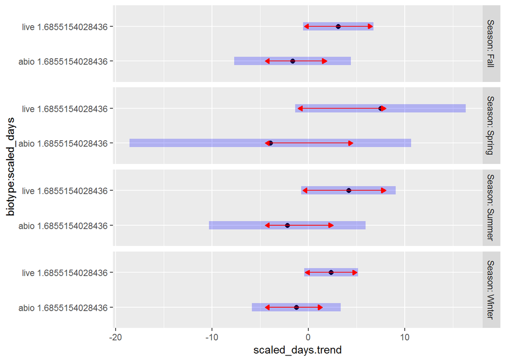

```r
plot(PFBA.emtrends, by = "Season", comparison = TRUE)
```

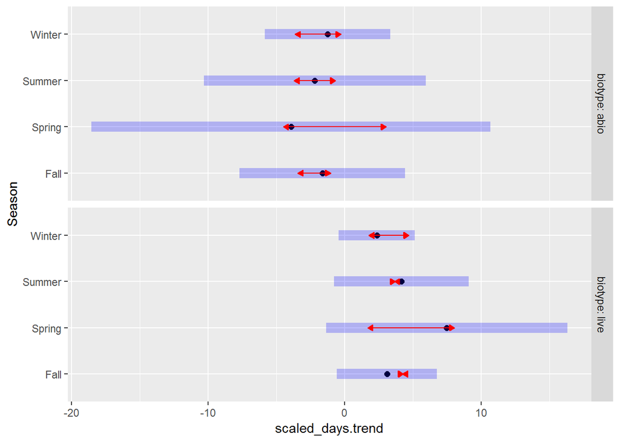

```r
plot(emtrends(model, ~ Season + biotype, var = "scaled_days", transform = "response"), by = "biotype", comparison = TRUE)
```

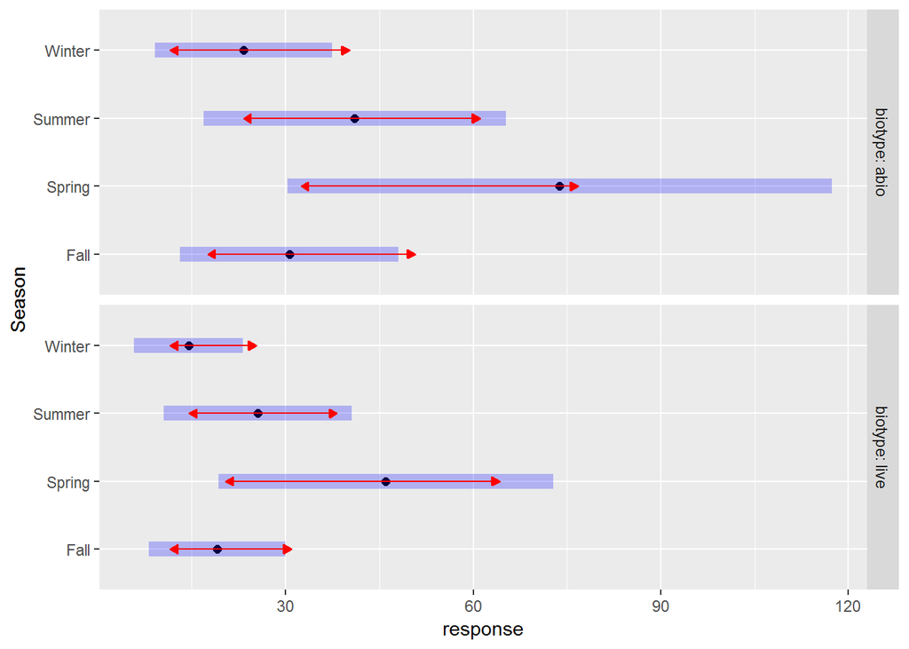

```r
plot(emmeans(model, ~ Season + biotype , transform = "response"), by = "biotype", comparison = TRUE)
```

```r
#emmip(model, ~ Season | biotype, transform = "response") +
#  theme_bw()+
#  geom_hline(yintercept = LOQs[chosen_PFAS], linetype = 2)
```

### PFPeA

Select PFPeA for individual compound analysis. Exploratory graphs.

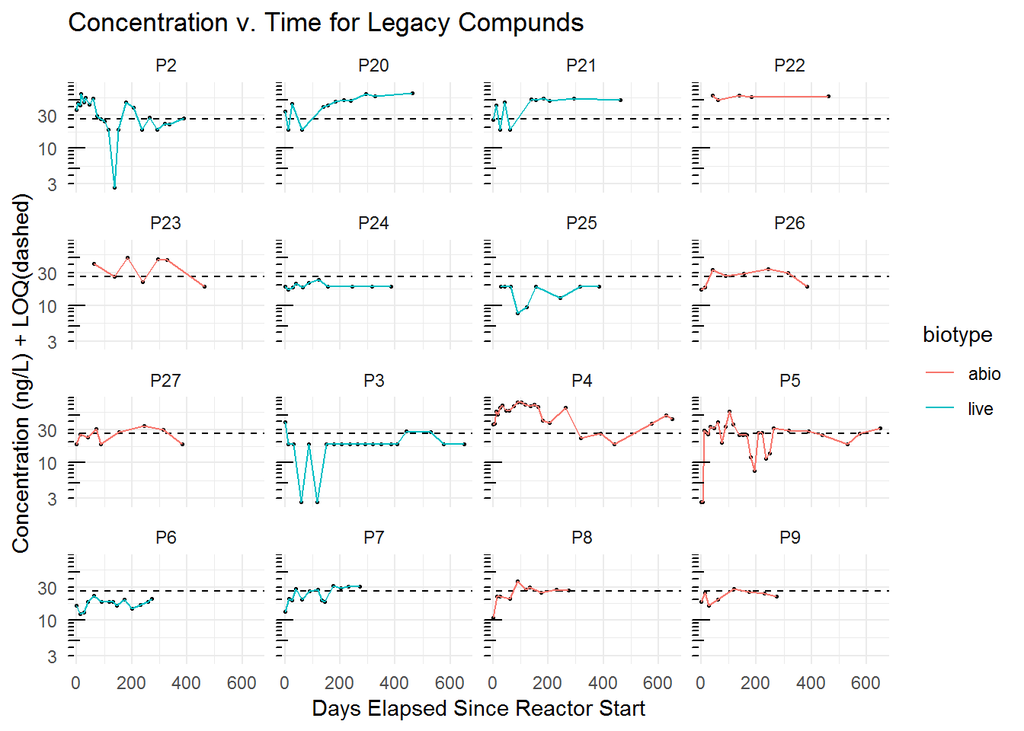

```r
chosen_PFAS <- "PFPeA"

single_PFAS <- filter(summary_plot, PFAS == chosen_PFAS)

levels(single_PFAS$phase) <- c("lag", "peak","decline")

ggplot(single_PFAS) +
  geom_hline(yintercept = LOQs[chosen_PFAS], linetype = 2)+
  theme_minimal()+
  geom_point(aes(x = Days.Elapsed, y = raw_measure, group = Reactor), size = 0.5) +
  geom_line(aes(x = Days.Elapsed, y = raw_measure, group = Reactor, color = biotype)) +
  scale_y_log10() +
  annotation_logticks(sides = "l")+
  facet_wrap(~Reactor) +
  labs(title ="Concentration v. Time for Legacy Compunds",
       x ="Days Elapsed Since Reactor Start",
       y ="Concentration (ng/L) + LOQ(dashed)")
```

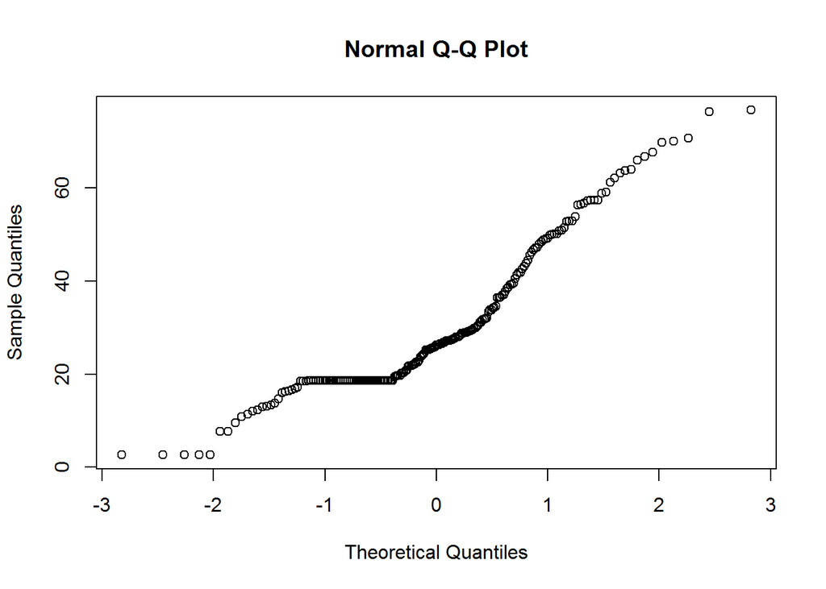

```r
qqnorm(single_PFAS$raw_measure)
```

Single value inputation is pretty clear from the QQ plot. LOQ is slightly high (30ng/L) so ~50% of measures should be some inputed value.

#### PFPeA Multi-Value Inputation

Fit a log-normal distribution based on truncated distribution with censored data (using *fitdistrplus*)

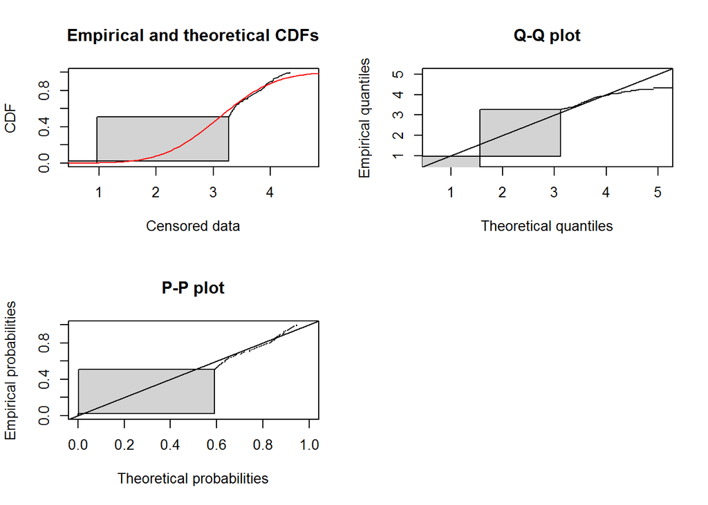

```r
fitting_values <- tibble(raw_measure = single_PFAS$raw_measure) %>%
  mutate(index1 = seq_len(nrow(.))) %>%
  sample_n(size = nrow(.)) %>%
  mutate(index2 = seq_len(nrow(.)))

lower_bound <- round(LOQs[chosen_PFAS]/10, 5)
sqrtloq <- round(LOQs[chosen_PFAS]/sqrt(2), 5)
cutoff <- round(LOQs[chosen_PFAS],5)

fitting_values <-  fitting_values %>%
  arrange(raw_measure) %>%
  mutate(raw_measure = round(raw_measure, 5)) %>%
  mutate(left = case_when(raw_measure <= lower_bound ~ as.numeric(NA),
                          raw_measure <= cutoff ~ lower_bound,
                          TRUE ~ raw_measure)) %>%
  mutate(right = case_when(raw_measure == lower_bound ~ lower_bound,
                           raw_measure <= cutoff ~ cutoff,
                           TRUE ~ raw_measure)) %>%
  arrange(raw_measure)

censdata <- fitting_values[c("left","right")] %>% as.data.frame() %>% arrange(left)

trunc_dist <- fitdistcens(log(censdata), distr = "norm")

plot(trunc_dist)
```

Fairly long tail on the QQ-plot high side, we really are inputing 50% of the data so I am not sure it is actually meaningful.

#### PFPeA Multi-Point Inputation

Going to do multi-point inputation instead of single point inputation. Assigned a random index to each censored data point, then fit with quantiles from the distribution fit above.

```r
trunc_quantiles <- unlist(quantile(trunc_dist, probs = seq(0,100,by=(100/(max(fitting_values$index1)+2)))/100)[1])[-1]

lowestcens <- sum(fitting_values$raw_measure <= lower_bound)
lowercens <- sum(fitting_values$raw_measure <= cutoff) - lowestcens

lowestcens_quatiles <- trunc_quantiles[1:lowestcens]
lowercens_quantiles <- trunc_quantiles[(lowestcens+1):(lowestcens+lowercens)]

inputions <- c(lowestcens_quatiles,lowercens_quantiles)

length(inputions) <- nrow(fitting_values)

inputed_frame <- cbind(fitting_values, inputions) %>%
  arrange(index1) %>%
  mutate(quantiles = ifelse(is.na(inputions), log(raw_measure), inputions)) %>%
  dplyr::select(quantiles) %>%
  cbind(single_PFAS) %>%
  mutate(conc = ifelse(raw_measure < LOQs[chosen_PFAS], exp(quantiles) * dil, raw_measure*dil)) %>%
  left_join(codings) %>%
  mutate(scaled_days = Days.Elapsed/100)
```

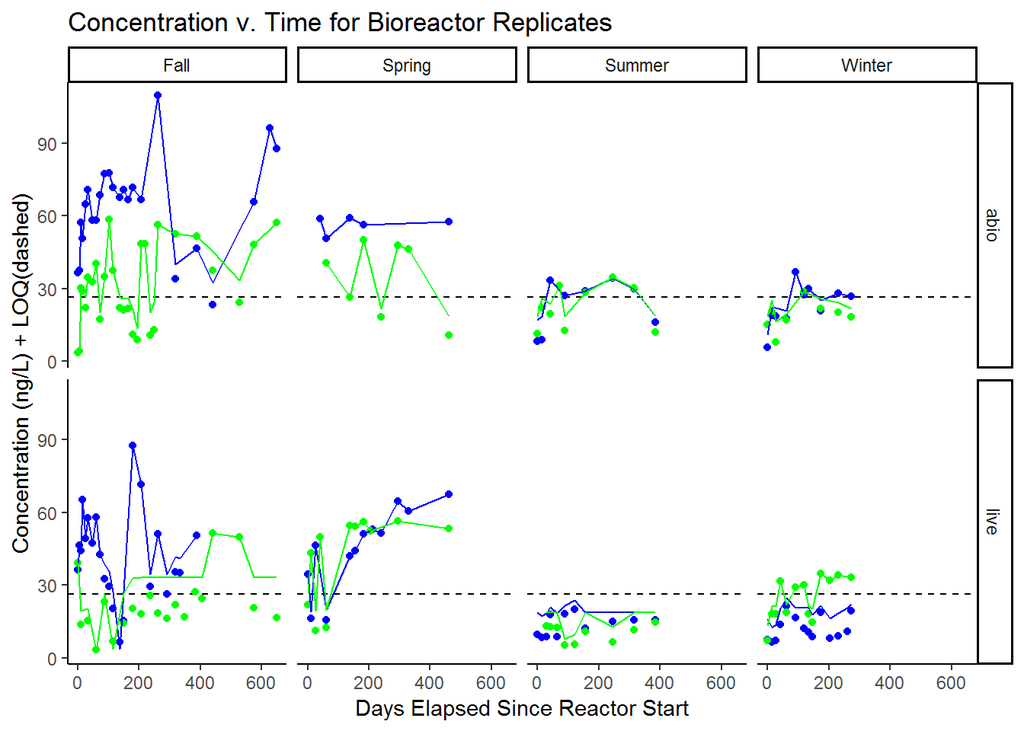

Inputed data points overlaid on line plot of original reported values

```r
graph <- ggplot(inputed_frame, aes(x = Days.Elapsed, group = Reactor)) +
  theme_classic()+
  guides(color = FALSE, fill =FALSE, linetype = FALSE)+
  geom_hline(yintercept = LOQs[chosen_PFAS], linetype = 2) +
  geom_point(aes(y = conc,
                 color = as.factor(dummy_rep))) +
  geom_line(aes(y = raw_measure*dil,
                color = as.factor(dummy_rep))) +
  scale_color_manual(values = c("blue","green"))+
  facet_grid(biotype~Season) +
  labs(title ="Concentration v. Time for Bioreactor Replicates",
       x ="Days Elapsed Since Reactor Start",
       y ="Concentration (ng/L) + LOQ(dashed)")

plot(graph)
```

Added noise should allow for modeling.

#### PFPeA Modeling

Building linear mixed effect models to account for experimental factors and nesting of Reactor %in% Season. Using scaled_days (Days/100) to allow for model convergence, this effect can be reversed during model interpretation.

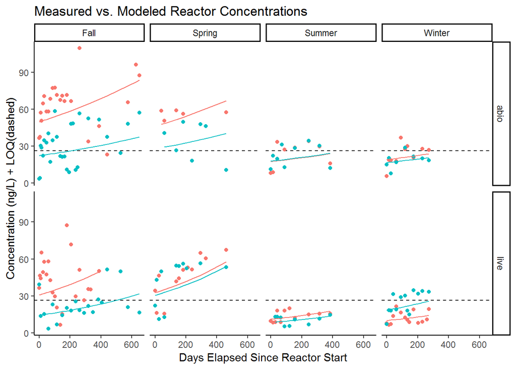

```r
model <- lmer(data = inputed_frame,
              log(conc) ~ scaled_days * biotype + Season + (1|Reactor))

ggplot(inputed_frame, aes(x = Days.Elapsed, group = Reactor)) +
  theme_classic()+
  guides(color = FALSE, fill =FALSE, linetype = FALSE)+
  geom_hline(yintercept = LOQs[chosen_PFAS], linetype = 2) +
  geom_point(aes(y = conc,
                 color = as.factor(dummy_rep))) +
  geom_line(aes(y = exp(predict(model)),
                color = as.factor(dummy_rep))) +
  facet_grid(biotype~Season) +
  labs(title ="Measured vs. Modeled Reactor Concentrations",
       x ="Days Elapsed Since Reactor Start",
       y ="Concentration (ng/L) + LOQ(dashed)")
```

#### Post-Hoc Comparison Testing

Model summary:

```r
summary(model)
```

```
## Linear mixed model fit by REML ['lmerMod']
## Formula: log(conc) ~ scaled_days * biotype + Season + (1 | Reactor)
##    Data: inputed_frame
##
## REML criterion at convergence: 354.4
##
## Scaled residuals:
##     Min      1Q  Median      3Q     Max
## -3.5918 -0.5161  0.2255  0.6651  1.9736
##
## Random effects:
##  Groups   Name        Variance Std.Dev.
##  Reactor  (Intercept) 0.1204   0.3469
##  Residual             0.2593   0.5092
## Number of obs: 211, groups:  Reactor, 16
##
## Fixed effects:
##                         Estimate Std. Error t value
## (Intercept)              3.45974    0.21270  16.266
## scaled_days              0.08003    0.03226   2.481
## biotypelive             -0.36803    0.20568  -1.789
## SeasonSpring             0.24019    0.26693   0.900
## SeasonSummer            -0.70295    0.26501  -2.653
## SeasonWinter            -0.52616    0.26343  -1.997
## scaled_days:biotypelive  0.04310    0.04870   0.885
##
## Correlation of Fixed Effects:
##             (Intr) scld_d btyplv SsnSpr SsnSmm SsnWnt
## scaled_days -0.276
## biotypelive -0.470  0.262
## SeasonSprng -0.566 -0.008 -0.036
## SeasonSummr -0.589  0.028 -0.012  0.466
## SeasonWintr -0.596  0.050 -0.017  0.469  0.475
## scld_dys:bt  0.154 -0.660 -0.385  0.027  0.011  0.010
```

```r
afex::mixed(model, data = inputed_frame)
```

```
## Formula (the first argument) converted to formula.
```

```
## Numerical variables NOT centered on 0: scaled_days
## If in interactions, interpretation of lower order (e.g., main) effects difficult.
```

```
## Fitting one lmer() model. [DONE]
## Calculating p-values. [DONE]
```

```
## Mixed Model Anova Table (Type 3 tests, KR-method)
##
## Model: log(conc) ~ scaled_days * biotype + Season + (1 | Reactor)
## Data: inputed_frame
##                Effect        df         F p.value
## 1         scaled_days 1, 195.48 17.25 ***  <.0001
## 2             biotype  1, 15.04    3.20 +     .09
## 3              Season  3, 11.03    5.24 *     .02
## 4 scaled_days:biotype 1, 197.46      0.78     .38
## ---
## Signif. codes:  0 '***' 0.001 '**' 0.01 '*' 0.05 '+' 0.1 ' ' 1
```

```r
PFPeA.emtrends.model <- emtrends(model, ~ Season + biotype + scaled_days:biotype, var = "scaled_days", transform = "response")
PFPeA.emmeans.model <- emmeans(model, ~Season + biotype + scaled_days:biotype, transform = "response")

CLD(PFPeA.emtrends.model)
```

```
##  Season biotype scaled_days scaled_days.trend        SE     df  lower.CL
##  Summer abio       1.685515          1.442481 0.5820851 195.12 0.2944949
##  Summer live       1.685515          1.651787 0.4919486 197.49 0.6816399
##  Winter abio       1.685515          1.721428 0.6946488 195.12 0.3514444
##  Winter live       1.685515          1.971209 0.5870818 197.49 0.8134556
##  Fall   abio       1.685515          2.913388 1.1756410 195.12 0.5947932
##  Fall   live       1.685515          3.336124 0.9935919 197.49 1.3767127
##  Spring abio       1.685515          3.704338 1.4948134 195.12 0.7562724
##  Spring live       1.685515          4.241842 1.2633401 197.49 1.7504735
##  upper.CL .group
##  2.590467  1234
##  2.621933  1
##  3.091412  1234
##  3.128963   2
##  5.231983  1234
##  5.295536    3
##  6.652403  1234
##  6.733210     4
##
## Trends are obtained after back-transforming from the log scale
## Confidence level used: 0.95
## P value adjustment: tukey method for comparing a family of 8 estimates
## significance level used: alpha = 0.05
```

```r
CLD(PFPeA.emmeans.model)
```

```
##  Season biotype scaled_days response        SE    df  lower.CL upper.CL
##  Summer live       1.685515 13.41413  2.876397 11.45  7.113642 19.71463
##  Winter live       1.685515 16.00816  3.385052 10.81  8.541917 23.47441
##  Summer abio       1.685515 18.02363  3.886391 11.70  9.531834 26.51542
##  Winter abio       1.685515 21.50904  4.607691 11.38 11.408688 31.60939
##  Fall   live       1.685515 27.09262  5.559539  9.62 14.637676 39.54756
##  Spring live       1.685515 34.44793  7.398790 11.48 18.245961 50.64991
##  Fall   abio       1.685515 36.40244  7.446428  9.47 19.684840 53.12003
##  Spring abio       1.685515 46.28526 10.215430 12.65 24.154188 68.41633
##  .group
##   1
##   1
##   1
##   1
##   1
##   1
##   1
##   1
##
## Degrees-of-freedom method: kenward-roger
## Confidence level used: 0.95
## P value adjustment: tukey method for comparing a family of 8 estimates
## significance level used: alpha = 0.05
```

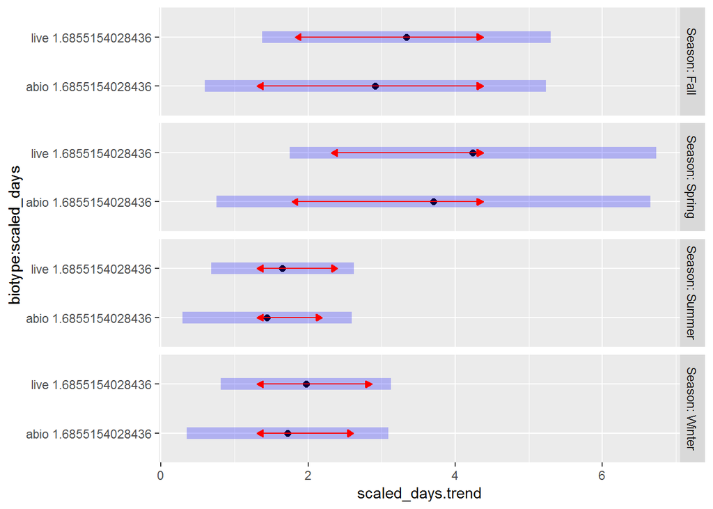

```r
plot(PFPeA.emtrends.model, by = "Season", comparison = TRUE)
```

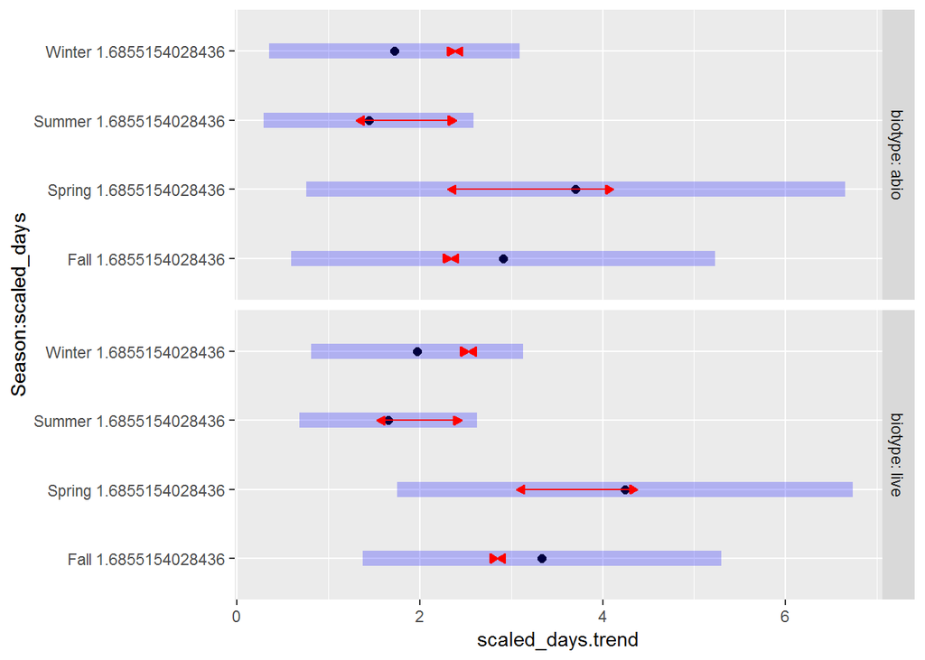

```r
plot(PFPeA.emtrends.model, by = "biotype", comparison = TRUE)
```

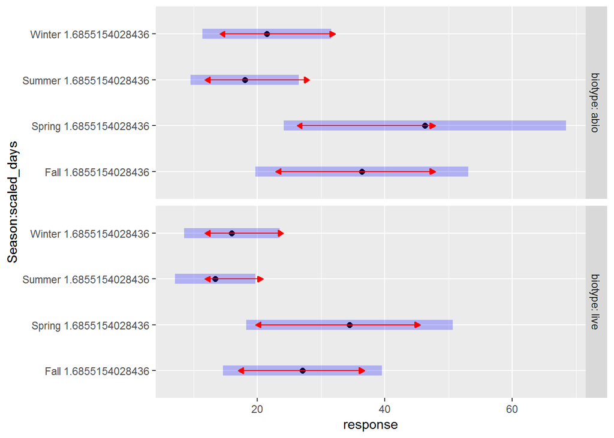

```r
plot(PFPeA.emmeans.model, by = "biotype", comparison = TRUE)
```

```r
#emmip(model, ~ Season | biotype, transform = "response") +
#  theme_bw()+
#  geom_hline(yintercept = LOQs[chosen_PFAS], linetype = 2)
```

### PFHxA

Select PFHxA for individual compound analysis. Exploratory graphs.

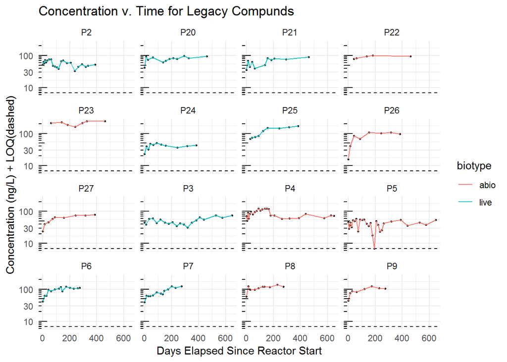

```r
chosen_PFAS <- "PFHxA"

single_PFAS <- filter(summary_plot, PFAS == chosen_PFAS)

levels(single_PFAS$phase) <- c("lag", "peak","decline")

ggplot(single_PFAS) +
  geom_hline(yintercept = LOQs[chosen_PFAS], linetype = 2)+
  theme_minimal()+
  geom_point(aes(x = Days.Elapsed, y = raw_measure, group = Reactor), size = 0.5) +
  geom_line(aes(x = Days.Elapsed, y = raw_measure, group = Reactor, color = biotype)) +
  scale_y_log10() +
  annotation_logticks(sides = "l")+
  facet_wrap(~Reactor) +
  labs(title ="Concentration v. Time for Legacy Compunds",
       x ="Days Elapsed Since Reactor Start",
       y ="Concentration (ng/L) + LOQ(dashed)")
```

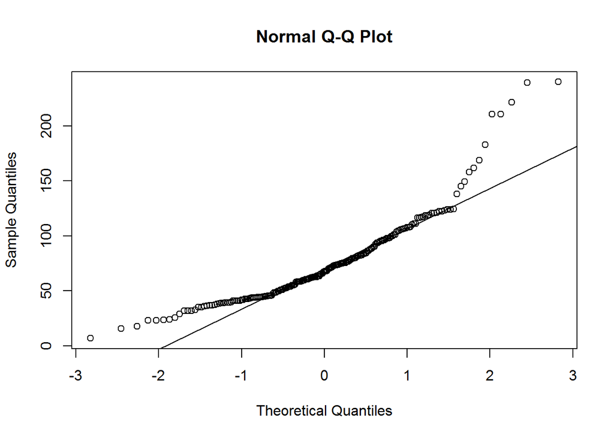

```r
unscaled_qq <- function() {
qqnorm(single_PFAS$raw_measure)
qqline(single_PFAS$raw_measure)
}

unscaled_qq()
```

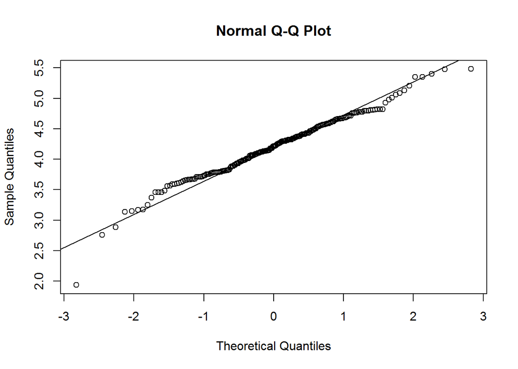

```r
log_qq <- function() {
  qqnorm(log(single_PFAS$raw_measure))
qqline(log(single_PFAS$raw_measure))
}

log_qq()
```

#### PFHxA Multi-Value Inputation

Fit a log-normal distribution based on truncated distribution with censored data (using *fitdistrplus*)

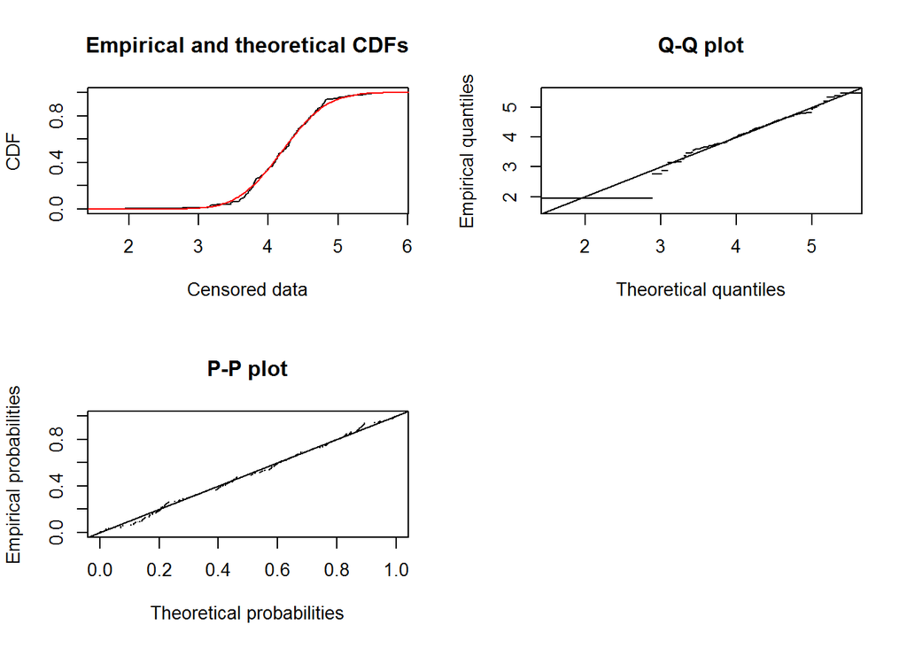

```r
fitting_values <- tibble(raw_measure = single_PFAS$raw_measure) %>%
  mutate(index1 = seq_len(nrow(.))) %>%
  sample_n(size = nrow(.)) %>%
  mutate(index2 = seq_len(nrow(.)))

lower_bound <- round(LOQs[chosen_PFAS]/10, 5)
sqrtloq <- round(LOQs[chosen_PFAS]/sqrt(2), 5)
cutoff <- round(LOQs[chosen_PFAS],5)

fitting_values <-  fitting_values %>%
  arrange(raw_measure) %>%
  mutate(raw_measure = round(raw_measure, 5)) %>%
  mutate(left = case_when(raw_measure <= lower_bound ~ as.numeric(NA),
                          raw_measure <= cutoff ~ lower_bound,
                          TRUE ~ raw_measure)) %>%
  mutate(right = case_when(raw_measure == lower_bound ~ lower_bound,
                           raw_measure <= cutoff ~ cutoff,
                           TRUE ~ raw_measure)) %>%
  arrange(raw_measure)

censdata <- fitting_values[c("left","right")] %>% as.data.frame() %>% arrange(left)

trunc_dist <- fitdistcens(log(censdata), distr = "norm")

plot(trunc_dist)
```

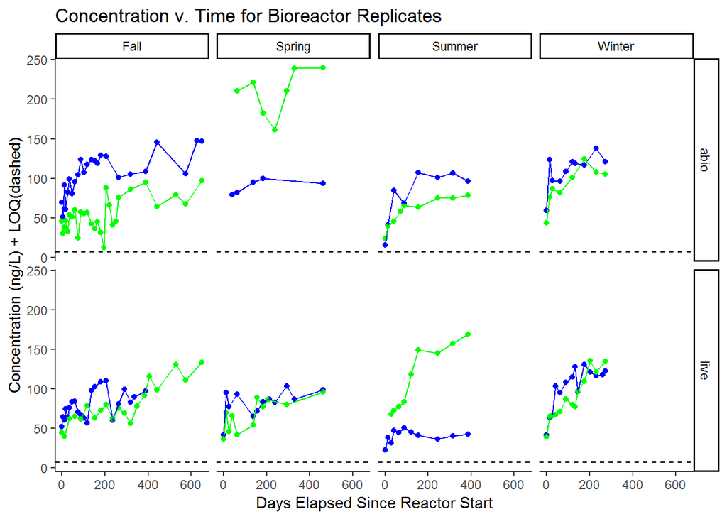

Inputed data points overlaid on line plot of original reported values

#### PFHxA Modeling

Building linear mixed effect models to account for experimental factors and nesting of Reactor %in% Season. Using scaled_days (Days/100) to allow for model convergence, this effect can be reversed during model interpretation.

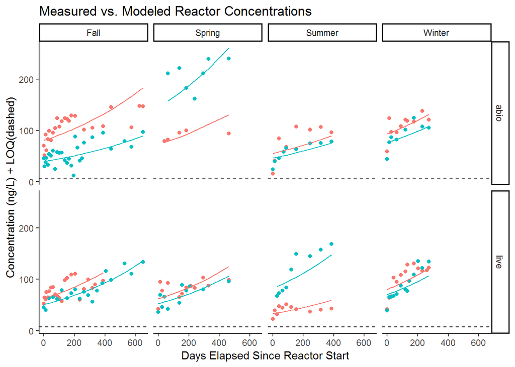

```r
model <- lmer(data = inputed_frame,
              log(conc) ~ scaled_days * biotype + Season + (1|Reactor))

ggplot(inputed_frame, aes(x = Days.Elapsed, group = Reactor)) +
  theme_classic()+
  guides(color = FALSE, fill =FALSE, linetype = FALSE)+
  geom_hline(yintercept = LOQs[chosen_PFAS], linetype = 2) +
  geom_point(aes(y = conc,
                 color = as.factor(dummy_rep))) +
  geom_line(aes(y = exp(predict(model)),
                color = as.factor(dummy_rep))) +
  facet_grid(biotype~Season) +
  labs(title ="Measured vs. Modeled Reactor Concentrations",
       x ="Days Elapsed Since Reactor Start",
       y ="Concentration (ng/L) + LOQ(dashed)")
```

#### Post-Hoc Comparison Testing

Model summary:

```r
summary(model)
```

```
## Linear mixed model fit by REML ['lmerMod']
## Formula: log(conc) ~ scaled_days * biotype + Season + (1 | Reactor)
##    Data: inputed_frame
##
## REML criterion at convergence: 106
##
## Scaled residuals:
##     Min      1Q  Median      3Q     Max
## -5.2427 -0.5164  0.0880  0.6648  2.0289
##
## Random effects:
##  Groups   Name        Variance Std.Dev.
##  Reactor  (Intercept) 0.11909  0.3451
##  Residual             0.07219  0.2687
## Number of obs: 211, groups:  Reactor, 16
##
## Fixed effects:
##                         Estimate Std. Error t value
## (Intercept)              4.11485    0.19837  20.744
## scaled_days              0.12643    0.01706   7.412
## biotypelive             -0.16794    0.18221  -0.922
## SeasonSpring             0.30859    0.25032   1.233
## SeasonSummer            -0.09152    0.24969  -0.367
## SeasonWinter             0.34740    0.24923   1.394
## scaled_days:biotypelive  0.02538    0.02581   0.984
##
## Correlation of Fixed Effects:
##             (Intr) scld_d btyplv SsnSpr SsnSmm SsnWnt
## scaled_days -0.156
## biotypelive -0.455  0.156
## SeasonSprng -0.611 -0.005 -0.013
## SeasonSummr -0.619  0.015 -0.004  0.489
## SeasonWintr -0.621  0.028 -0.006  0.490  0.492
## scld_dys:bt  0.087 -0.660 -0.229  0.016  0.006  0.005
```

```r
afex::mixed(model, data = inputed_frame)
```

```
## Formula (the first argument) converted to formula.
```

```
## Numerical variables NOT centered on 0: scaled_days
## If in interactions, interpretation of lower order (e.g., main) effects difficult.
```

```
## Fitting one lmer() model. [DONE]
## Calculating p-values. [DONE]
```

```
## Mixed Model Anova Table (Type 3 tests, KR-method)
##
## Model: log(conc) ~ scaled_days * biotype + Season + (1 | Reactor)
## Data: inputed_frame
##                Effect        df          F p.value
## 1         scaled_days 1, 193.77 115.94 ***  <.0001
## 2             biotype  1, 12.24       0.85     .37
## 3              Season  3, 11.01       1.53     .26
## 4 scaled_days:biotype 1, 194.46       0.97     .33
## ---
## Signif. codes:  0 '***' 0.001 '**' 0.01 '*' 0.05 '+' 0.1 ' ' 1
```

### PFHpA

Select PFHpA for individual compound analysis. Exploratory graphs.

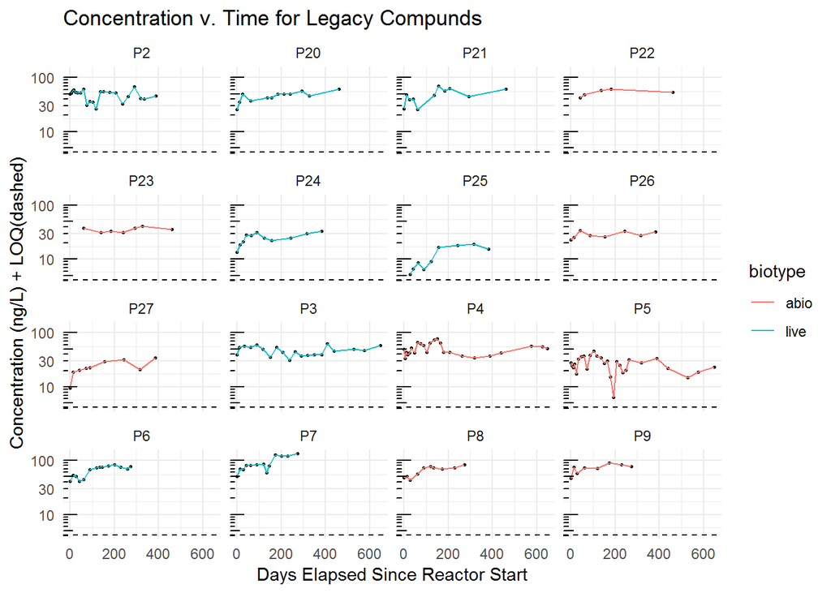

```r
chosen_PFAS <- "PFHpA"

single_PFAS <- filter(summary_plot, PFAS == chosen_PFAS)

levels(single_PFAS$phase) <- c("lag", "peak","decline")

ggplot(single_PFAS) +
  geom_hline(yintercept = LOQs[chosen_PFAS], linetype = 2)+
  theme_minimal()+
  geom_point(aes(x = Days.Elapsed, y = raw_measure, group = Reactor), size = 0.5) +
  geom_line(aes(x = Days.Elapsed, y = raw_measure, group = Reactor, color = biotype)) +
  scale_y_log10() +
  annotation_logticks(sides = "l")+
  facet_wrap(~Reactor) +
  labs(title ="Concentration v. Time for Legacy Compunds",
       x ="Days Elapsed Since Reactor Start",
       y ="Concentration (ng/L) + LOQ(dashed)")
```

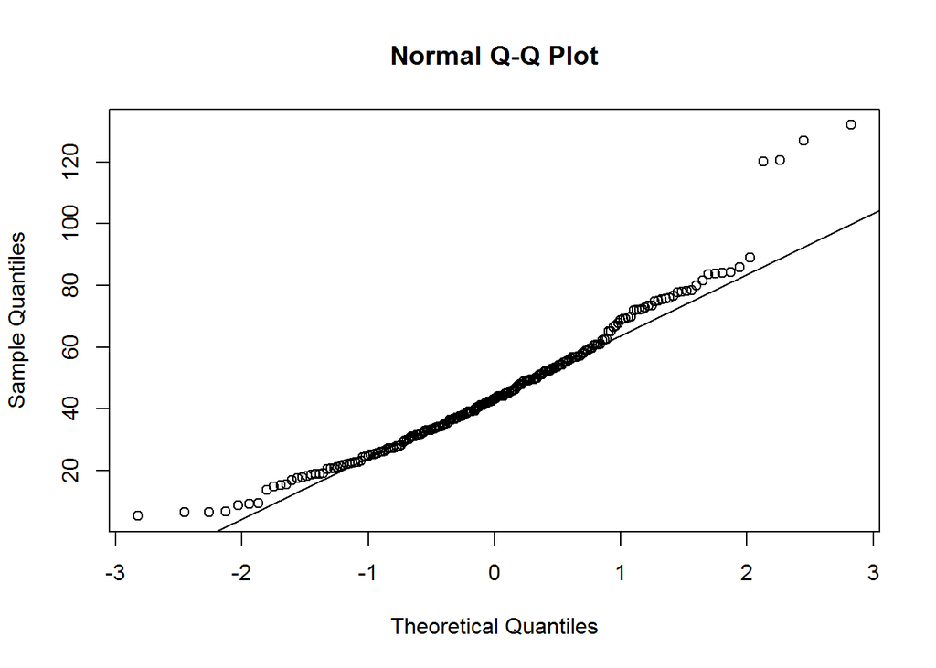

```r
unscaled_qq <- function() {
qqnorm(single_PFAS$raw_measure)
qqline(single_PFAS$raw_measure)
}

unscaled_qq()
```

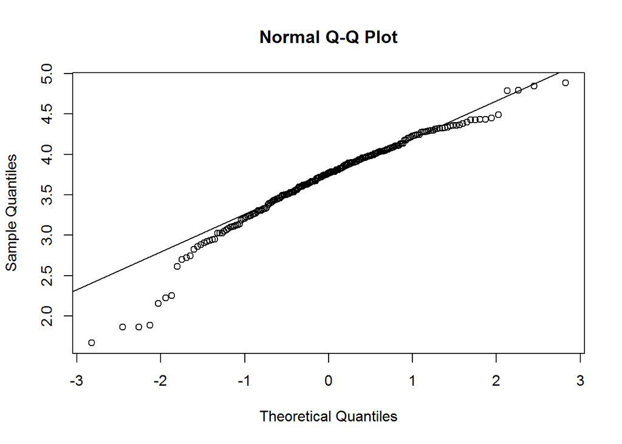

```r
log_qq <- function() {
  qqnorm(log(single_PFAS$raw_measure))
qqline(log(single_PFAS$raw_measure))
}

log_qq()
```

QQ plot almost normal, log-scaling clears upper end long tail. Using log-scaled data for consistent modeling.

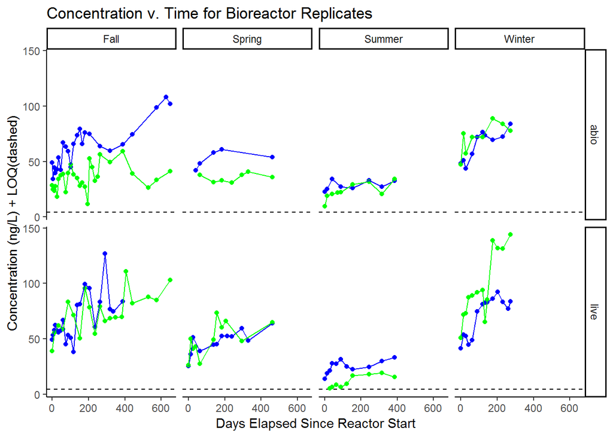

#### PFHpA Modeling

Building linear mixed effect models to account for experimental factors and nesting of Reactor %in% Season. Using scaled_days (Days/100) to allow for model convergence, this effect can be reversed during model interpretation.

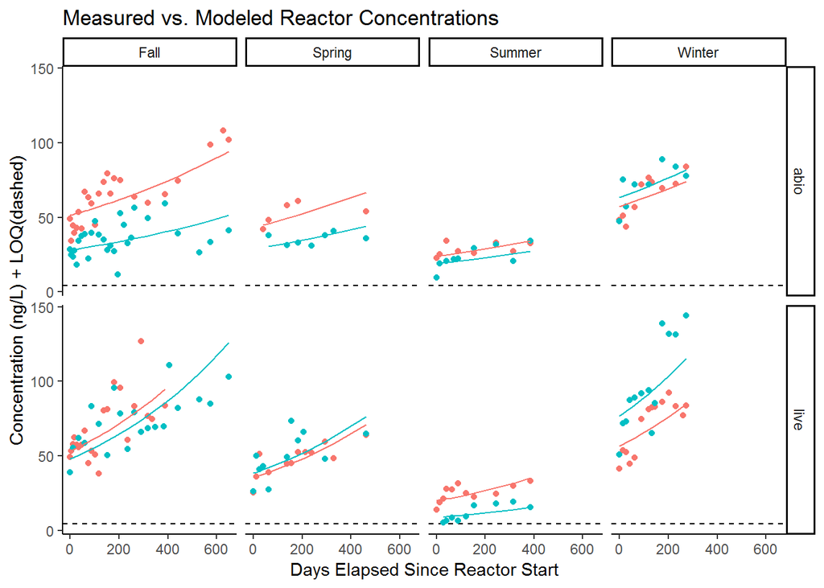

```r
model <- lmer(data = inputed_frame,
              log(conc) ~ scaled_days * biotype + Season + (1|Reactor))

ggplot(inputed_frame, aes(x = Days.Elapsed, group = Reactor)) +
  theme_classic()+
  guides(color = FALSE, fill =FALSE, linetype = FALSE)+
  geom_hline(yintercept = LOQs[chosen_PFAS], linetype = 2) +
  geom_point(aes(y = conc,
                 color = as.factor(dummy_rep))) +
  geom_line(aes(y = exp(predict(model)),
                color = as.factor(dummy_rep))) +
  facet_grid(biotype~Season) +
  labs(title ="Measured vs. Modeled Reactor Concentrations",
       x ="Days Elapsed Since Reactor Start",
       y ="Concentration (ng/L) + LOQ(dashed)")
```

#### Post-Hoc Comparison Testing

Model summary:

```r
summary(model)
```

```
## Linear mixed model fit by REML ['lmerMod']
## Formula: log(conc) ~ scaled_days * biotype + Season + (1 | Reactor)
##    Data: inputed_frame
##
## REML criterion at convergence: 59.8
##
## Scaled residuals:
##     Min      1Q  Median      3Q     Max
## -4.4858 -0.5817  0.0657  0.6902  1.9131
##
## Random effects:
##  Groups   Name        Variance Std.Dev.
##  Reactor  (Intercept) 0.09850  0.3138
##  Residual             0.05745  0.2397
## Number of obs: 211, groups:  Reactor, 16
##
## Fixed effects:
##                         Estimate Std. Error t value
## (Intercept)              3.78493    0.18022  21.002
## scaled_days              0.09389    0.01521   6.171
## biotypelive             -0.01422    0.16539  -0.086
## SeasonSpring            -0.19295    0.22744  -0.848
## SeasonSummer            -0.96329    0.22689  -4.246
## SeasonWinter             0.36637    0.22649   1.618
## scaled_days:biotypelive  0.05492    0.02302   2.386
##
## Correlation of Fixed Effects:
##             (Intr) scld_d btyplv SsnSpr SsnSmm SsnWnt
## scaled_days -0.153
## biotypelive -0.454  0.154
## SeasonSprng -0.612 -0.005 -0.012
## SeasonSummr -0.619  0.015 -0.004  0.490
## SeasonWintr -0.621  0.028 -0.005  0.490  0.492
## scld_dys:bt  0.085 -0.660 -0.225  0.015  0.006  0.005
```

```r
afex::mixed(model, data = inputed_frame)
```

```
## Formula (the first argument) converted to formula.
```

```
## Numerical variables NOT centered on 0: scaled_days
## If in interactions, interpretation of lower order (e.g., main) effects difficult.
```

```
## Fitting one lmer() model. [DONE]
## Calculating p-values. [DONE]
```

```
## Mixed Model Anova Table (Type 3 tests, KR-method)
##
## Model: log(conc) ~ scaled_days * biotype + Season + (1 | Reactor)
## Data: inputed_frame
##                Effect        df          F p.value
## 1         scaled_days 1, 193.74 110.86 ***  <.0001
## 2             biotype  1, 12.19       0.01     .93
## 3              Season  3, 11.01  12.06 ***   .0008
## 4 scaled_days:biotype 1, 194.41     5.68 *     .02
## ---
## Signif. codes:  0 '***' 0.001 '**' 0.01 '*' 0.05 '+' 0.1 ' ' 1
```

```r
PFHpA.emtrends.model <- emtrends(model, ~ Season + biotype + scaled_days:biotype, var = "scaled_days", transform = "response")
PFHpA.emmeans.model <- emmeans(model, ~Season + biotype + scaled_days:biotype, transform = "response")

CLD(PFHpA.emtrends.model)
```

```
##  Season biotype scaled_days scaled_days.trend        SE     df lower.CL
##  Summer abio       1.685515          1.848195 0.2996164 193.69 1.257265
##  Summer live       1.685515          3.168086 0.3683672 194.37 2.441577
##  Spring abio       1.685515          3.993020 0.6473205 193.69 2.716318
##  Fall   abio       1.685515          4.842816 0.7850833 193.69 3.294406
##  Spring live       1.685515          6.844643 0.7958563 194.37 5.275020
##  Winter abio       1.685515          6.985714 1.1324750 193.69 4.752148
##  Fall   live       1.685515          8.301321 0.9652306 194.37 6.397651
##  Winter live       1.685515         11.974574 1.3923357 194.37 9.228549
##   upper.CL .group
##   2.439124  1
##   3.894596  123
##   5.269722   2 4
##   6.391225    3 56
##   8.414266     45 7
##   9.219280        789
##  10.204991       6 8
##  14.720600          9
##
## Trends are obtained after back-transforming from the log scale
## Confidence level used: 0.95
## P value adjustment: tukey method for comparing a family of 8 estimates
## significance level used: alpha = 0.05
```

```r
CLD(PFHpA.emmeans.model)
```

```
##  Season biotype scaled_days response        SE    df lower.CL  upper.CL
##  Summer abio       1.685515 19.68563  3.562669 11.20 11.86089  27.51036
##  Summer live       1.685515 21.28998  3.846249 11.12 12.83534  29.74462
##  Spring abio       1.685515 42.53075  7.757870 11.53 25.55171  59.50979
##  Spring live       1.685515 45.99695  8.315158 11.14 27.72357  64.27033
##  Fall   abio       1.685515 51.58215  9.187224 10.50 31.24348  71.92082
##  Fall   live       1.685515 55.78603  9.944703 10.54 33.78092  77.79114
##  Winter abio       1.685515 74.40675 13.438954 11.10 44.86150 103.95200
##  Winter live       1.685515 80.47080 14.475952 10.93 48.58357 112.35803
##  .group
##   1
##   12
##   123
##   123
##   123
##   123
##    23
##     3
##
## Degrees-of-freedom method: kenward-roger
## Confidence level used: 0.95
## P value adjustment: tukey method for comparing a family of 8 estimates
## significance level used: alpha = 0.05
```

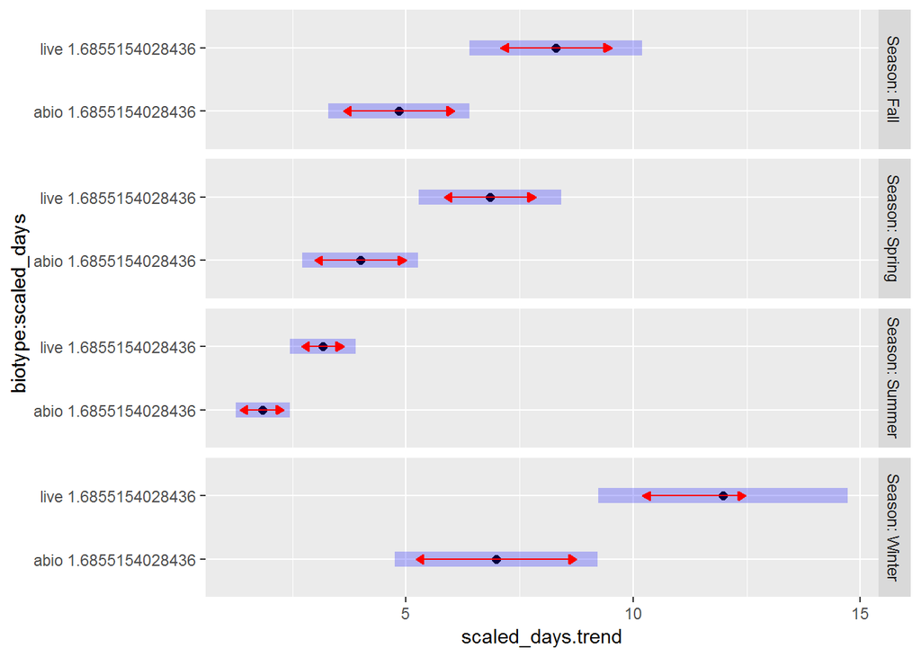

```r
plot(PFHpA.emtrends.model, by = "Season", comparison = TRUE)
```

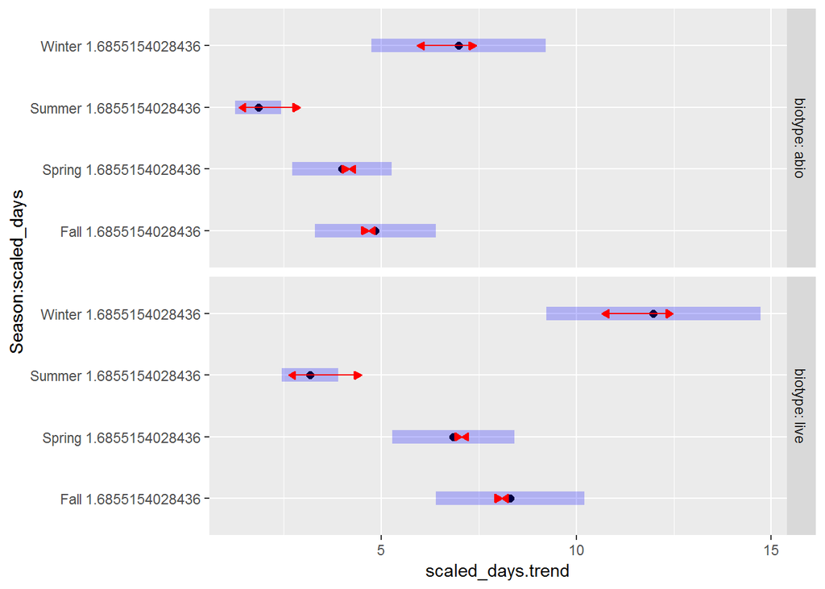

```r
plot(PFHpA.emtrends.model, by = "biotype", comparison = TRUE)
```

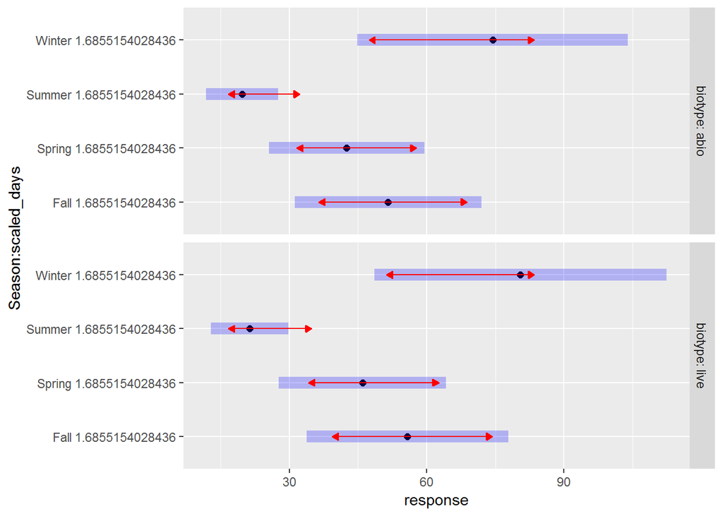

```r
plot(PFHpA.emmeans.model, by = "biotype", comparison = TRUE)
```

```r
#emmip(model, ~ Season | biotype, transform = "response") +
#  theme_bw()+
#  geom_hline(yintercept = LOQs[chosen_PFAS], linetype = 2)
```